# 260-2017-10-02

2017-09-26 16:23:17

## Identify the structure

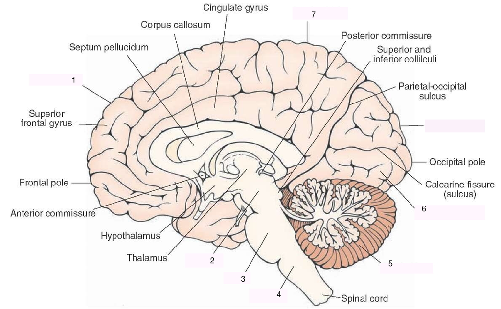

## Identify the structure

\(1\) Frontal lobe  
\(2\) Midbrain  
\(3\) Pons  
\(4\) Medulla

## Identify the structure

\(5\) Cerebellum  
\(6\) Occipital lobe  
\(7\) Parietal lobe

\(8\) These tissues provide external structural support and protection for the CNS.

- Astrocytes
- Meninges
- Cerebral ventricles
- Circle of Willis

\(8\) These tissues provide external structural support and protection for the CNS.

- Astrocytes
- **Meninges**
- Cerebral ventricles
- Circle of Willis

- Coronal
- Sagittal
- Axial/horizontal
- Dorsal

- Coronal
- Sagittal
- **Axial/horizontal**
- Dorsal

- Coronal
- Sagittal
- Axial/horizontal
- Dorsal

- Coronal
- **Sagittal**
- Axial/horizontal
- Dorsal

- Coronal
- Sagittal
- Axial/horizontal
- Dorsal

- **Coronal**
- Sagittal
- Axial/horizontal
- Dorsal

- Superior temporal sulcus
- Central sulcus
- Longitudinal fissure
- Lateral fissure

- Superior temporal sulcus
- Central sulcus
- Longitudinal fissure
- **Lateral fissure**

\(13\) Primary somatosensory cortex (SI) is found in the ????.

- Temporal lobe
- Frontal lobe
- Hypothalamus
- Basal ganglia
- Parietal lobe

\(13\) Primary somatosensory cortex (SI) is found in the ????.

- Temporal lobe
- Frontal lobe
- Hypothalamus
- Basal ganglia
- **Parietal lobe**

\(14\) Which of the following statements about neurons is *incorrect*?

- Neurons have very long lives.
- Neurons can extend over long distances.
- Neurons are the only cells that have negative resting potentials.
- Neurons use both electrical and chemical mechanisms to communicate.

\(14\) Which of the following statements about neurons is *incorrect*?

- Neurons have very long lives.
- Neurons can extend over long distances.
- **Neurons are the only cells that have negative resting potentials.**
- Neurons use both electrical and chemical mechanisms to communicate.

\(15\) Primary motor cortex is found in the ????.

- Temporal lobe
- Frontal lobe
- Hypothalamus
- Basal ganglia
- Parietal lobe

\(15\) Primary motor cortex is found in the ????.

- Temporal lobe
- **Frontal lobe**
- Hypothalamus
- Basal ganglia
- Parietal lobe

\(16\) Your grandmother has a stroke. The neurologist chooses an X-ray-based structural brain imaging method that gives satisfactory, but not especially detailed spatial resolution. What method is that?

- Computed tomography (CT).
- functional MRI.
- Positron Emission Tomography (PET).
- Anterograde tract tracers.

\(16\) Your grandmother has a stroke. The neurologist chooses an X-ray-based structural brain imaging method that gives satisfactory, but not especially detailed spatial resolution. What method is that?

- **Computed tomography (CT).**
- functional MRI.
- Positron Emission Tomography (PET).
- Anterograde tract tracers.

\(17\) Which of the following structures are *not* part of the basal ganglia?

- Caudate nucleus
- Globus pallidus
- Putamen
- Fornix

\(17\) Which of the following structures are *not* part of the basal ganglia?

- Caudate nucleus
- Globus pallidus
- Putamen
- **Fornix**

\(18\) The ???? plays a role in biologically crucial behaviors, including those associated with ingestion (eating and drinking) and reproduction.

- Temporal lobe
- Frontal lobe
- Hypothalamus
- Basal ganglia
- Parietal lobe

\(18\) The ???? plays a role in biologically crucial behaviors, including those associated with ingestion (eating and drinking) and reproduction.

- Temporal lobe
- Frontal lobe
- **Hypothalamus**
- Basal ganglia
- Parietal lobe

\(19\) What maintains the intracellular (inside)/extracellular (outside) concentration differences of \(K^+\) and \(Na^+\) ions? .

- the myelin sheath.
- the force of diffusion.
- **action of the \(Na^+\)/\(K^+\) pump.**
- ion flow through passive/leak channels.

\(19\) What maintains the intracellular (inside)/extracellular (outside) concentration differences of \(K^+\) and \(Na^+\) ions? .

- the myelin sheath.
- the force of diffusion.
- **action of the \(Na^+\)/\(K^+\) pump.**
- ion flow through passive/leak channels.

\(20\) The tough, canvas-like tissue that surrounds and protects the ???? is called ????.

- white matter; cerebrospinal fluid (CSF)
- gray matter; myelin
- central nervous system (CNS); dura mater
- cerebral ventricles; endothelial cells

\(20\) The tough, canvas-like tissue that surrounds and protects the ???? is called ????.

- white matter; cerebrospinal fluid (CSF)
- gray matter; myelin
- **central nervous system (CNS); dura mater**
- cerebral ventricles; endothelial cells

\(21\) Scientists are exploring how chronic conditions like depression can change the size and shape of brain structures using high spatial resolution whole brain imaging techniques like ????.

- electroencephalography (EEG).
- hemodynamic response imaging.
- structural MRI.
- Computed Tomography (CT).

\(21\) Scientists are exploring how chronic conditions like depression can change the size and shape of brain structures using high spatial resolution whole brain imaging techniques like ????.

- electroencephalography (EEG).
- hemodynamic response imaging.
- **structural MRI.**
- Computed Tomography (CT).

\(22\) How many neurons are there in the human brain?

- **About 86 billion**.
- About 86 million.
- About the same number of seconds as in the average lifetime.
- It can’t be estimated.

\(23\) This type of glial cell provides neurons in the peripheral nervous system (PNS) with a myelin sheath.

- **Schwann cells**
- Oligodendrocytes
- Microglia
- Purkinje cells

\(24\) The hippocampus plays a central role in ????.

- Sexual behavior
- Metabolic, physical support of neurons
- Sensory relay processing
- **Memory storage and retrieval**
- CNS protection

\(25\) The sympathetic nervous system is crucial for ????.

- Sexual behavior
- Metabolic, physical support of neurons
- Sensory relay processing
- Preparation for action
- CNS protection

\(25\) The sympathetic nervous system is crucial for ????.

- Sexual behavior
- Metabolic, physical support of neurons
- Sensory relay processing
- **Preparation for action**
- CNS protection

\(26\) Sodium (\(Na^+\)) is highly concentrated ????. This means that the force of diffusion acting alone will push \(Na^+\) ????.

- inside; inward
- outside; inward
- inside; outward
- outside; outward

\(26\) Sodium (\(Na^+\)) is highly concentrated ????. This means that the force of diffusion acting alone will push \(Na^+\) ????.

- inside; inward
- **outside; inward**
- inside; outward
- outside; outward

\(27\) You’re having trouble sleeping, so your physician orders a sleep study using polysomnography. You spend a night in the hospital with electrodes on your scalp. This is an example use case of ????.

- electroencephalograpy (EEG).
- Multi-unit recording.
- transcranial magnetic stimulation.
- optical imaging.

\(27\) You’re having trouble sleeping, so your physician orders a sleep study using polysomnography. You spend a night in the hospital with electrodes on your scalp. This is an example use case of ????.

- **electroencephalograpy (EEG)**.
- Multi-unit recording.
- transcranial magnetic stimulation.
- optical imaging.

\(28\) ????, a type of glial cell, help regulate local blood oxygen levels in response to neuronal activity. These cells thus contribute to the signal measured by ????.

- oligodendrocytes; MEG
- Schwann cells; structural MRI
- astrocytes; functional MRI
- microglia; structural and functional MRI

\(28\) ????, a type of glial cell, help regulate local blood oxygen levels in response to neuronal activity. These cells thus contribute to the signal measured by ????.

- oligodendrocytes; MEG
- Schwann cells; structural MRI
- **astrocytes; functional MRI**
- microglia; structural and functional MRI

\(29\) Which ventral midbrain region is one of the main sites for neurons that relase neuromodulators (e.g., dopamine, norepinephrine, and serotonin)?

- Basal ganglia
- Lateral geniculate nucleus
- Tegmentum
- Tectum

\(29\) Which ventral midbrain region is one of the main sites for neurons that relase neuromodulators (e.g., dopamine, norepinephrine, and serotonin)?

- Basal ganglia
- Lateral geniculate nucleus
- **Tegmentum**
- Tectum

\(30\) The hypothalamus is NOT responsible for which of the following functions?

- Fleeing
- Feeding
- Fighting
- Falling

\(30\) The hypothalamus is NOT responsible for which of the following functions?

- Fleeing
- Feeding
- Fighting
- **Falling**

\(31\) Which of the following marks the medial boundary of the frontal lobe?

- Lateral fissure
- Longitudinal fissure
- Central sulcus
- Inferior temporal gyrus

\(31\) Which of the following marks the medial boundary of the frontal lobe?

- Lateral fissure
- **Longitudinal fissure**
- Central sulcus
- Inferior temporal gyrus

\(32\) Nodes of Ranvier, or gaps in the myelination of an axon, serve which purpose?

- Increase the speed of propagation.
- Allow space in the axon for neurotransmitter release.
- Provide structural support to the neuron.
- Combine input from different dendrites.

\(32\) Nodes of Ranvier, or gaps in the myelination of an axon, serve which purpose?

- **Increase the speed of propagation**.
- Allow space in the axon for neurotransmitter release.
- Provide structural support to the neuron.
- Combine input from different dendrites.

\(33\) Descartes thought that this midbrain structure was the place where the soul interacted with the body to create movement by inflating the muscles.

- Pons
- Cerebral aqueduct
- Pineal gland
- Superior colliclus

\(33\) Descartes thought that this midbrain structure was the place where the soul interacted with the body to create movement by inflating the muscles.

- Pons
- Cerebral aqueduct
- **Pineal gland**
- Superior colliclus

\(34\) When a neuron’ membrane potential is “at rest,” which of the following ions are more heavily concentrated *inside* of the cell?

- \(Na^+\) and \(Cl^-\)
- \(K^+\) and \(A^-\)
- \(Na^+\) and \(K^+\)
- \(Cl^-\) and \(A^-\)

\(34\) When a neuron’ membrane potential is “at rest,” which of the following ions are more heavily concentrated *inside* of the cell?

- \(Na^+\) and \(Cl^-\)
- **\(K^+\) and \(A^-\)**
- \(Na^+\) and \(K^+\)
- \(Cl^-\) and \(A^-\)

\(35\) When a neuron’s membrane potential reaches the *threshold* for an action potential, ????.

- voltage-gated \(K^+\) channels close
- voltage-gated \(Na^+\) channels close and inactivate
- the Na/K pump works even harder to keep the concentration balance.
- voltage-gated \(Na^+\) channels open

\(36\) This part of the cell functions as the neuron’s “antennae” by serving as the primary place for receiving input.

- Axon
- Soma
- Dendrites
- Terminal Buttons

\(36\) This part of the cell functions as the neuron’s “antennae” by serving as the primary place for receiving input.

- Axon
- Soma
- **Dendrites**
- Terminal Buttons

\(37\) During the *falling* phase of the action potential, ???? channels ????.

- Ligand-gated \(K^+\); close
- Voltage-gated \(Na^+\); close
- Voltage-gated \(Na^+\); open
- Voltage-gated \(K^+\); remain open

\(37\) During the *falling* phase of the action potential, ???? channels ????.

- Ligand-gated \(K^+\); close
- Voltage-gated \(Na^+\); close
- Voltage-gated \(Na^+\); open
- **Voltage-gated \(K^+\); remain open**

\(38\) The speed of electrical signaling via action potentials is ???? the speed of chemical signalling via diffusion.

- much faster than
- much slower than
- about the same speed as
- slightly slower than

\(38\) The speed of electrical signaling via action potentials is ???? the speed of chemical signalling via diffusion.

- **much faster than**
- much slower than
- about the same speed as
- slightly slower than

\(39\) During the *absolute* refractory period, a neuron will ????.

- fire again in response to an especially strong input.
- produce an action potential that is twice the normal size.
- open voltage-gated Ca++ channels.
- not fire no matter the strength of the input.

\(39\) During the *absolute* refractory period, a neuron will ????.

- fire again in response to an especially strong input.
- produce an action potential that is twice the normal size.
- open voltage-gated Ca++ channels.
- **not fire no matter the strength of the input**.

\(40\) All of the following ions move across the neuronal membrane at different times *EXCEPT*

- \(Na^+\)
- \(K^+\)
- \(Cl^-\)
- Organic anions (\(A^-\))

\(40\) All of the following ions move across the neuronal membrane at different times *EXCEPT*

- \(Na^+\)
- \(K^+\)
- \(Cl^-\)
- **Organic anions (\(A^-\))**

## Bonus

\(41\) During the *rising* phase of the action potential, ???? ions ????.

- \(K^+\); flow out
- \(Na^+\); flow out
- \(K^+\); flow in
- \(Na^+\); flow in

## Bonus

\(41\) During the *rising* phase of the action potential, ???? ions ????.

- \(K^+\); flow out
- \(Na^+\); flow out
- \(K^+\); flow in
- **\(Na^+\); flow in**

\(42\) The ????, a large axon fiber bundle that connects the two cerebral hemispheres, lies deep within the ????.

- anterior commissure; superior longitudinal fissure
- posterior commissure; post-central gyrus
- corticospinal tract; brainstem
- corpus callosum; superior longitudinal fissure

\(42\) The ????, a large axon fiber bundle that connects the two cerebral hemispheres, lies deep within the ????.

- anterior commissure; superior longitudinal fissure
- posterior commissure; post-central gyrus
- corticospinal tract; brainstem
- **corpus callosum; superior longitudinal fissure**

\(43\) In a typical neuron near or slightly above its resting potential chloride (\(Cl^-\)) ions would flow following the concentration gradient. This would move the neuron its firing threshold.

- Inward; farther from
- Inward; closer to
- Outward; farther from
- Outward; closer to

\(43\) In a typical neuron near or slightly above its resting potential chloride (\(Cl^-\)) ions would flow following the concentration gradient. This would move the neuron its firing threshold.

- **Inward; farther from**
- Inward; closer to
- Outward; farther from
- Outward; closer to

\(44\) A toxin found in Japanese pufferfish blocks voltage-gated \(Na^+\) channels. Applying such a toxin to neurons would have what effect?

- Slower falling phase of the action potential.
- Increasing the concentration of \(Na^+\) inside the cell.
- \(K^+\) ions would accelerate their flow to compensate.
- Action potentials would be abolished.

\(44\) A toxin found in Japanese pufferfish blocks voltage-gated \(Na^+\) channels. Applying such a toxin to neurons would have what effect?

- Slower falling phase of the action potential.
- Increasing the concentration of \(Na^+\) inside the cell.
- \(K^+\) ions would accelerate their flow to compensate.
- **Action potentials would be abolished.**